# Prueba_adres_ilich

## Razon_No_Estudio_p6218

| Feature | Result |
| --- | --- |
| Variable type | character |
| Number of missing obs. | 390923 (77.46 %) |
| Number of unique values | 15 |
| Mode | “Necesita trabajar” |

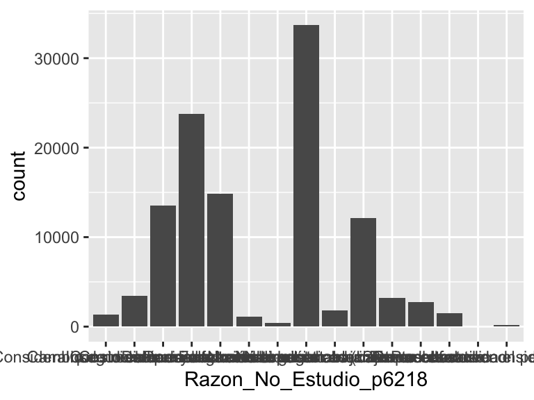

- Note that the following levels have at most five observations: "Por situaciones académicas (bajos resultados en el periodo académico, repetición de cursos".

## Razon_No_Estudio_Agregada_p6218

| Feature | Result |
| --- | --- |
| Variable type | character |
| Number of missing obs. | 390923 (77.46 %) |
| Number of unique values | 2 |
| Mode | “Barreras_Acceso” |

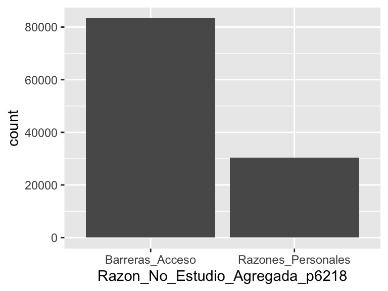

## Nivel_Educativo_Actual_p8587

| Feature | Result |
| --- | --- |
| Variable type | character |
| Number of missing obs. | 176005 (34.88 %) |
| Number of unique values | 13 |
| Mode | “Primaria” |

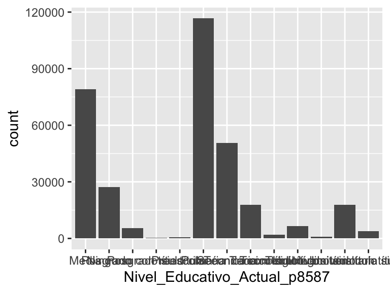

## Nivel_Educativo_Alcanzado_p1088

| Feature | Result |
| --- | --- |
| Variable type | character |
| Number of missing obs. | 367131 (72.75 %) |
| Number of unique values | 8 |
| Mode | “Primaria” |

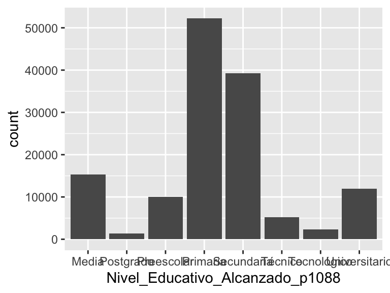

## Anos_de_Educacion

| Feature | Result |
| --- | --- |
| Variable type | numeric |
| Number of missing obs. | 0 (0 %) |
| Number of unique values | 32 |
| Median | 5 |
| 1st and 3rd quartiles | 2; 11 |
| Min. and max. | 0; 31 |

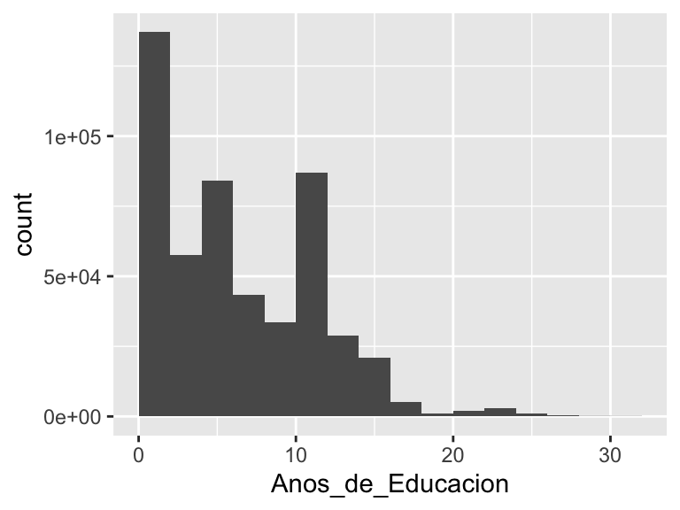

## Anos_de_Educacion.jefe

| Feature | Result |
| --- | --- |
| Variable type | numeric |
| Number of missing obs. | 0 (0 %) |
| Number of unique values | 32 |
| Median | 0 |
| 1st and 3rd quartiles | 0; 2 |
| Min. and max. | 0; 31 |

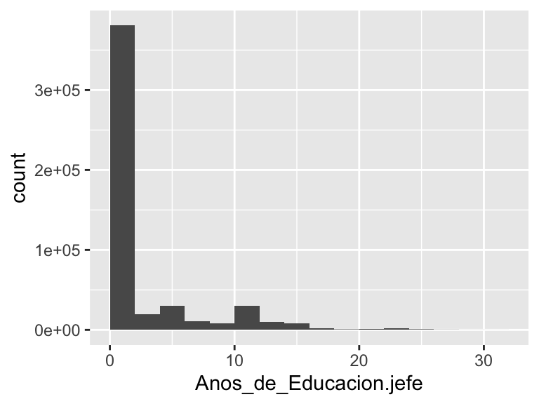

## Analfabetismo_IPM

| Feature | Result |
| --- | --- |
| Variable type | character |
| Number of missing obs. | 0 (0 %) |
| Number of unique values | 2 |
| Mode | “No” |

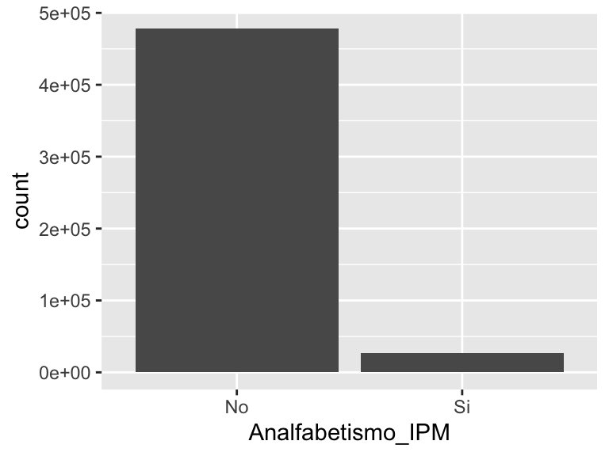

## Rezago_Escolar_IPM

| Feature | Result |
| --- | --- |
| Variable type | character |
| Number of missing obs. | 399906 (79.24 %) |
| Number of unique values | 2 |
| Mode | “Si” |

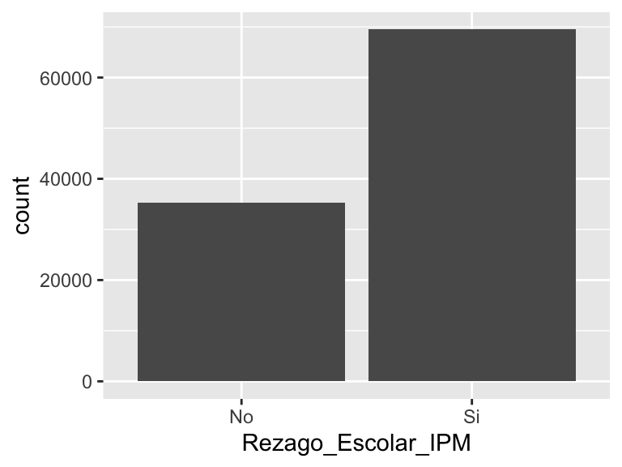

## Inasistencia_Escolar_IPM

| Feature | Result |
| --- | --- |
| Variable type | character |
| Number of missing obs. | 400430 (79.35 %) |
| Number of unique values | 2 |
| Mode | “No” |

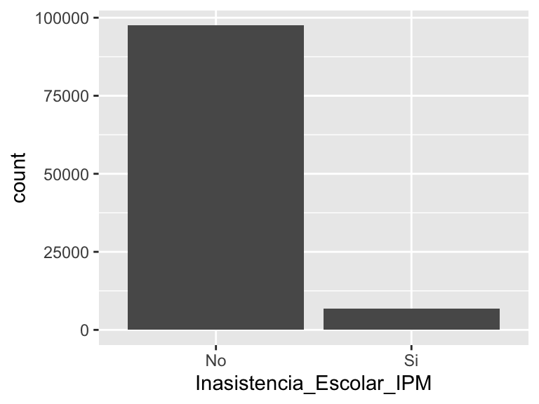

Report generation information:

- Created by: Ilich Herbert De La Hoz Siegler (username: `ilichherbertdelahozsiegler`).
- Report creation time: Sat Feb 03 2024 18:19:49
- Report was run from directory: `/Users/ilichherbertdelahozsiegler/Desktop/prueba_adres`
- R version 4.3.2 (2023-10-31).
- Platform: aarch64-apple-darwin20 (64-bit)(America/Bogota).